# R 코드와 함께 사용

# 옵션 익히기

R 실행에만 필요해 이후의 파일에는 포함가 없는 경우에 사용하는 옵션. include로 결정한다. 전체 문서의 디폴트를 설정하는 코드

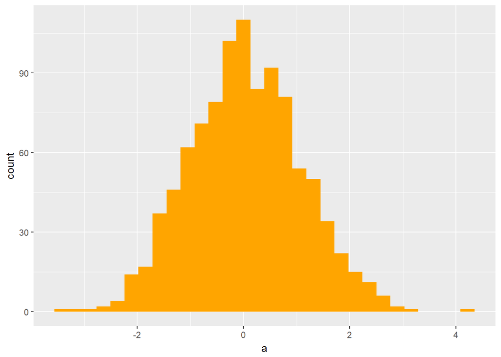

```r
a<- rnorm(1000)
df<-as.data.frame(a)
ggplot(df,aes(a))+geom_histogram(fill='orange',bindwidth=0.3)
```

## 옵션 익히기 2

코드 청크가 지신이 가지고 있는 소스코드를 출력으로 할지 여부를 제어할 수 있다. 이것은 echo 옵션으로 TRUE 나 FALSE 혹은 숫자 값을 정할 수 있다. 디폴트는 TRUE다. echo=TRUE 면 출력하고 FALSE 는 출력하지 않는다. 숫자 값은 코드의 일부만 출력 할 때 사용한다. 예를 들어 echo=1:3 이면 1에서 3번 줄까지를 echo=-2는 2번 줄을 제외하라는 의미이다. echo=(1,3)은 1번과 3번줄을 출력 하라는 의미이다.

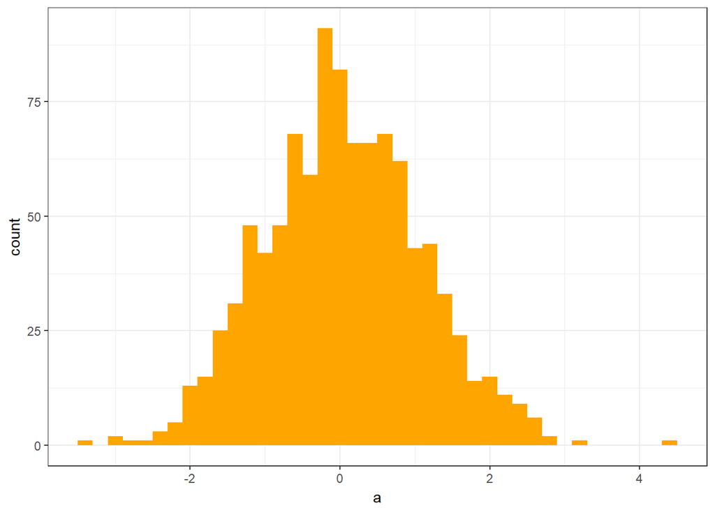

# 옵션 익히기

코드 청크가 어떤 조건에 맞을 때만 실행 되도록 할 수 있다. 처음 코드는 일종의 조절자 역할을 한다. 세번째 코드 청크에서는 ! 연산자를 사용해 부정하고 있다.

```r
dothis<-TRUE
```

참 이므로 결과로 실행

```r
head(iris)
```

```
##   Sepal.Length Sepal.Width Petal.Length Petal.Width Species
## 1          5.1         3.5          1.4         0.2  setosa
## 2          4.9         3.0          1.4         0.2  setosa
## 3          4.7         3.2          1.3         0.2  setosa
## 4          4.6         3.1          1.5         0.2  setosa
## 5          5.0         3.6          1.4         0.2  setosa
## 6          5.4         3.9          1.7         0.4  setosa
```

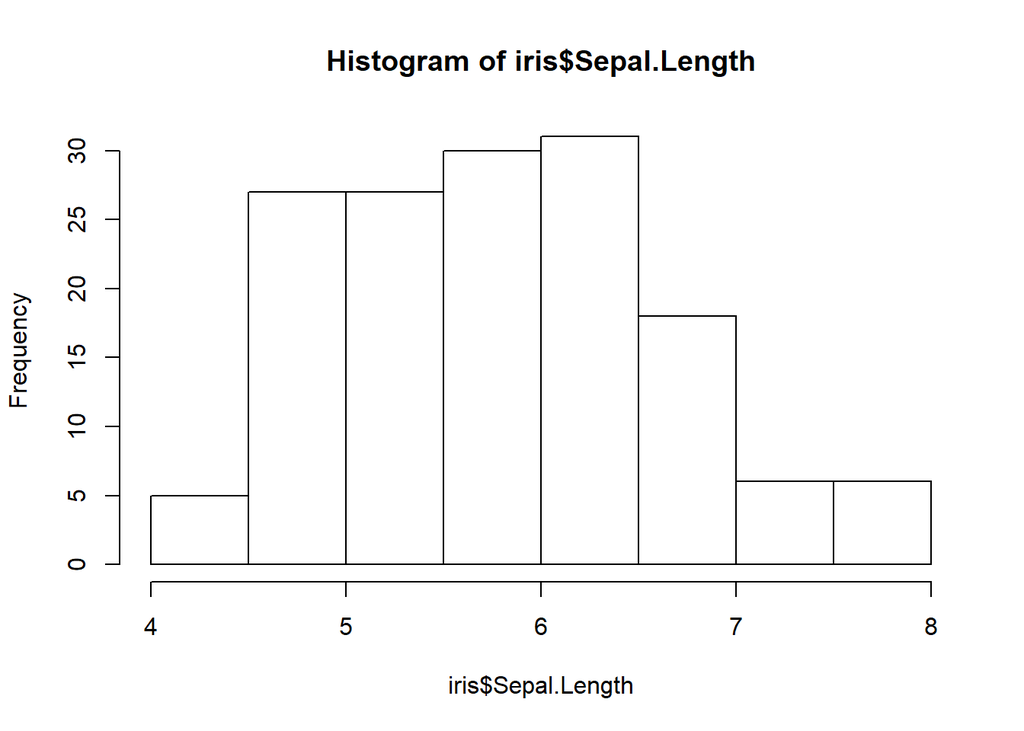

```r
hist(iris$Sepal.Length)
```

거짓 이므로 코드만 보임

```r
head(iris)
hist(iris$Spal.Length)
```

# 옵션 익히기3

```r
a<-sample(1:10,10,replace=TRUE)
f<-function(x){m<-mean(x);s<-sd(x);v<-var(x)
return(list(mean=m,sd=s,var=v))}

a
```

```
##  [1]  5  8  1  6  8 10  2  2  9 10
```

```r
f(a)
```

```
## $mean
## [1] 6.1
##
## $sd
## [1] 3.446415
##
## $var
## [1] 11.87778
```